# Aplicações de GeoAnálise - Estudo de Caso

```r
dest <- "./DADOS/SHP"
setwd("./DADOS/SHP")
url <- "ftp://geoftp.ibge.gov.br/organizacao_do_territorio/malhas_territoriais/malhas_de_setores_censitarios__divisoes_intramunicipais/censo_2010/setores_censitarios_shp/ac/ac_municipios.zip"
download.file(url = url, destfile = "ac_municipios.zip")
url <- "ftp://geoftp.ibge.gov.br/organizacao_do_territorio/malhas_territoriais/malhas_de_setores_censitarios__divisoes_intramunicipais/censo_2010/setores_censitarios_shp/al/al_municipios.zip"
download.file(url = url, destfile = "al_municipios.zip")
url <- "ftp://geoftp.ibge.gov.br/organizacao_do_territorio/malhas_territoriais/malhas_de_setores_censitarios__divisoes_intramunicipais/censo_2010/setores_censitarios_shp/am/am_municipios.zip"
download.file(url = url, destfile = "am_municipios.zip")
url <- "ftp://geoftp.ibge.gov.br/organizacao_do_territorio/malhas_territoriais/malhas_de_setores_censitarios__divisoes_intramunicipais/censo_2010/setores_censitarios_shp/ap/ap_municipios.zip"
download.file(url = url, destfile = "ap_municipios.zip")
url <- "ftp://geoftp.ibge.gov.br/organizacao_do_territorio/malhas_territoriais/malhas_de_setores_censitarios__divisoes_intramunicipais/censo_2010/setores_censitarios_shp/ba/ba_municipios.zip"
download.file(url = url, destfile = "ba_municipios.zip")
url <- "ftp://geoftp.ibge.gov.br/organizacao_do_territorio/malhas_territoriais/malhas_de_setores_censitarios__divisoes_intramunicipais/censo_2010/setores_censitarios_shp/ce/ce_municipios.zip"
download.file(url = url, destfile = "ce_municipios.zip")
url <- "ftp://geoftp.ibge.gov.br/organizacao_do_territorio/malhas_territoriais/malhas_de_setores_censitarios__divisoes_intramunicipais/censo_2010/setores_censitarios_shp/df/df_municipios.zip"
download.file(url = url, destfile = "df_municipios.zip")
url <- "ftp://geoftp.ibge.gov.br/organizacao_do_territorio/malhas_territoriais/malhas_de_setores_censitarios__divisoes_intramunicipais/censo_2010/setores_censitarios_shp/es/es_municipios.zip"
download.file(url = url, destfile = "es_municipios.zip")
url <- "ftp://geoftp.ibge.gov.br/organizacao_do_territorio/malhas_territoriais/malhas_de_setores_censitarios__divisoes_intramunicipais/censo_2010/setores_censitarios_shp/go/go_municipios.zip"
download.file(url = url, destfile = "go_municipios.zip")
url <- "ftp://geoftp.ibge.gov.br/organizacao_do_territorio/malhas_territoriais/malhas_de_setores_censitarios__divisoes_intramunicipais/censo_2010/setores_censitarios_shp/ma/ma_municipios.zip"
download.file(url = url, destfile = "ma_municipios.zip")
url <- "ftp://geoftp.ibge.gov.br/organizacao_do_territorio/malhas_territoriais/malhas_de_setores_censitarios__divisoes_intramunicipais/censo_2010/setores_censitarios_shp/mg/mg_municipios.zip"
download.file(url = url, destfile = "mg_municipios.zip")
url <- "ftp://geoftp.ibge.gov.br/organizacao_do_territorio/malhas_territoriais/malhas_de_setores_censitarios__divisoes_intramunicipais/censo_2010/setores_censitarios_shp/ms/ms_municipios.zip"
download.file(url = url, destfile = "ms_municipios.zip")
url <- "ftp://geoftp.ibge.gov.br/organizacao_do_territorio/malhas_territoriais/malhas_de_setores_censitarios__divisoes_intramunicipais/censo_2010/setores_censitarios_shp/mt/mt_municipios.zip"
download.file(url = url, destfile = "mt_municipios.zip")
url <- "ftp://geoftp.ibge.gov.br/organizacao_do_territorio/malhas_territoriais/malhas_de_setores_censitarios__divisoes_intramunicipais/censo_2010/setores_censitarios_shp/pa/pa_municipios.zip"
download.file(url = url, destfile = "pa_municipios.zip")
url <- "ftp://geoftp.ibge.gov.br/organizacao_do_territorio/malhas_territoriais/malhas_de_setores_censitarios__divisoes_intramunicipais/censo_2010/setores_censitarios_shp/pb/pb_municipios.zip"
download.file(url = url, destfile = "pb_municipios.zip")
url <- "ftp://geoftp.ibge.gov.br/organizacao_do_territorio/malhas_territoriais/malhas_de_setores_censitarios__divisoes_intramunicipais/censo_2010/setores_censitarios_shp/pe/pe_municipios.zip"
download.file(url = url, destfile = "pe_municipios.zip")
url <- "ftp://geoftp.ibge.gov.br/organizacao_do_territorio/malhas_territoriais/malhas_de_setores_censitarios__divisoes_intramunicipais/censo_2010/setores_censitarios_shp/pi/pi_municipios.zip"
download.file(url = url, destfile = "pi_municipios.zip")
url <- "ftp://geoftp.ibge.gov.br/organizacao_do_territorio/malhas_territoriais/malhas_de_setores_censitarios__divisoes_intramunicipais/censo_2010/setores_censitarios_shp/pr/pr_municipios.zip"
download.file(url = url, destfile = "pr_municipios.zip")
url <- "ftp://geoftp.ibge.gov.br/organizacao_do_territorio/malhas_territoriais/malhas_de_setores_censitarios__divisoes_intramunicipais/censo_2010/setores_censitarios_shp/rj/rj_municipios.zip"
download.file(url = url, destfile = "rj_municipios.zip")
url <- "ftp://geoftp.ibge.gov.br/organizacao_do_territorio/malhas_territoriais/malhas_de_setores_censitarios__divisoes_intramunicipais/censo_2010/setores_censitarios_shp/rn/rn_municipios.zip"
download.file(url = url, destfile = "rn_municipios.zip")
url <- "ftp://geoftp.ibge.gov.br/organizacao_do_territorio/malhas_territoriais/malhas_de_setores_censitarios__divisoes_intramunicipais/censo_2010/setores_censitarios_shp/ro/ro_municipios.zip"
download.file(url = url, destfile = "ro_municipios.zip")
url <- "ftp://geoftp.ibge.gov.br/organizacao_do_territorio/malhas_territoriais/malhas_de_setores_censitarios__divisoes_intramunicipais/censo_2010/setores_censitarios_shp/rr/rr_municipios.zip"
download.file(url = url, destfile = "rr_municipios.zip")
url <- "ftp://geoftp.ibge.gov.br/organizacao_do_territorio/malhas_territoriais/malhas_de_setores_censitarios__divisoes_intramunicipais/censo_2010/setores_censitarios_shp/rs/rs_municipios.zip"
download.file(url = url, destfile = "rs_municipios.zip")
url <- "ftp://geoftp.ibge.gov.br/organizacao_do_territorio/malhas_territoriais/malhas_de_setores_censitarios__divisoes_intramunicipais/censo_2010/setores_censitarios_shp/sc/sc_municipios.zip"
download.file(url = url, destfile = "sc_municipios.zip")
url <- "ftp://geoftp.ibge.gov.br/organizacao_do_territorio/malhas_territoriais/malhas_de_setores_censitarios__divisoes_intramunicipais/censo_2010/setores_censitarios_shp/se/se_municipios.zip"
download.file(url = url, destfile = "se_municipios.zip")
url <- "ftp://geoftp.ibge.gov.br/organizacao_do_territorio/malhas_territoriais/malhas_de_setores_censitarios__divisoes_intramunicipais/censo_2010/setores_censitarios_shp/sp/sp_municipios.zip"
download.file(url = url, destfile = "sp_municipios.zip")
url <- "ftp://geoftp.ibge.gov.br/organizacao_do_territorio/malhas_territoriais/malhas_de_setores_censitarios__divisoes_intramunicipais/censo_2010/setores_censitarios_shp/to/to_municipios.zip"
download.file(url = url, destfile = "to_municipios.zip")

arquivos <- list.files(path = dest
                       , pattern = "*.zip"
                       , full.names = TRUE)

do.call(rbind, lapply(arquivos
                      , function(x) unzip(x, exdir = dest)))

setwd("~/Tresors/zz-pessoal/FGV/git/Trabalhos/AGA")
```

Usando o QGIS juntamos os Shape Files para termos um mapa com os municípios do Brasil. Tentei usar o R para fazer este merge, mas não consegui de forma adequada

Lendo o Shapefile com os municípios no mapa do Brasil

```r
municip_br <- readOGR(dsn = "Municip_BR.shp"
                     , layer = "Municip_BR"
                     , verbose = TRUE
                     , use_iconv = TRUE
                     , p4s = "+proj=longlat +ellps=WGS84"
                     , encoding = "Latin1"
                     )
```

```
p4s= argument given as: +proj=longlat +ellps=WGS84
 and read as: +proj=longlat +datum=WGS84 +no_defs
 read string overridden by given p4s= argument value
```

```r
names(municip_br)
```

```
[1] "fid"        "CD_GEOCODM" "NM_MUNICIP"
```

```r
summary(municip_br)
```

```
Object of class SpatialPolygonsDataFrame
Coordinates:
        min        max
x -73.99045 -28.835908
y -33.75208   5.271841
Is projected: FALSE
proj4string : [+proj=longlat +ellps=WGS84]
Data attributes:
      fid         CD_GEOCODM                NM_MUNICIP
 Min.   :   1   1100015:   1   BOM JESUS         :   5
 1st Qu.:1392   1100023:   1   SÃ\u0083O DOMINGOS:   5
 Median :2784   1100031:   1   BONITO            :   4
 Mean   :2784   1100049:   1   PLANALTO          :   4
 3rd Qu.:4176   1100056:   1   SANTA HELENA      :   4
 Max.   :5567   1100064:   1   SANTA INÃ\u008aS  :   4
                (Other):5561   (Other)           :5541
```

```r
municip_br_bkp <- municip_br
```

Mapa do Brasil com os municípios, como no shapefile, sem tema:

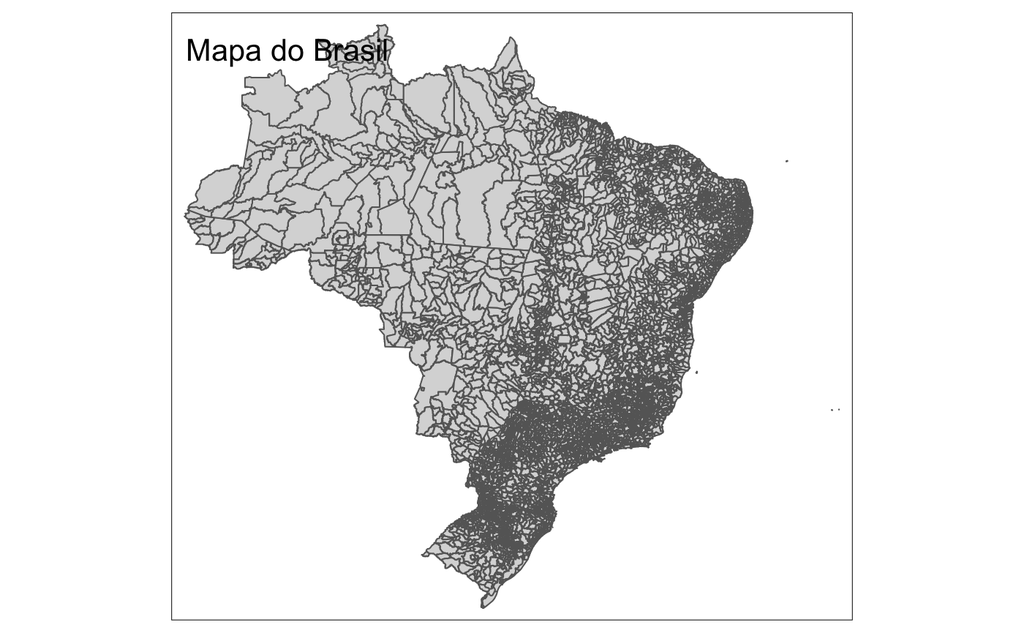

```r
url <- "http://ftp.dadosabertos.ans.gov.br/FTP/PDA/TISS/HOSPITALAR/2017/SP.zip"
dest <- "./DADOS/SP-H-2017.zip"
download.file(url = url, destfile = dest)

arquivos <- list.files(path = "./DADOS"
                       , pattern = "SP.*zip"
                       , full.names = TRUE)

do.call(rbind, lapply(arquivos
                      , function(x) unzip(x, exdir = "./DataSP")))
```

```r
arquivos <- list.files(path = "./DataSP"
                       , pattern = ".*HOSP.*CONS.*csv"
                       , full.names = TRUE)
dadosHospSP <- do.call(rbind
                          , lapply(arquivos
                                   , function(x) fread(x,encoding = "Latin-1")))
```

```r
CID1 <- setnames(within(dadosHospSP[!which(dadosHospSP$CID_1 == "")]
                        , rm("CID_2","CID_3","CID_4")),"CID_1", "CID")
CID2 <- setnames(within(dadosHospSP[!which(dadosHospSP$CID_2 == "")]
                        , rm("CID_1","CID_3","CID_4")),"CID_2", "CID")
CID3 <- setnames(within(dadosHospSP[!which(dadosHospSP$CID_3 == "")]
                        , rm("CID_2","CID_1","CID_4")),"CID_3", "CID")
CID4 <- setnames(within(dadosHospSP[!which(dadosHospSP$CID_4 == "")]
                        , rm("CID_2","CID_3","CID_1")),"CID_4", "CID")
dadosHospSP <- rbind(CID1, CID2, CID3, CID4)
rm(CID1, CID2, CID3, CID4)
dadosHospSP$CID <- substr(dadosHospSP$CID,1,3)
```

```r
dadosHospSP_min <- dadosHospSP[,c("CD_MUNIC_BENEFICIARIO","CD_MUNIC_PRESTADOR","DT_INTERNACAO","CID")]
dadosHospSP_min$DT_INTERNACAO <- as.Date(dadosHospSP_min$DT_INTERNACAO, format = "%d/%m/%Y")
summary(dadosHospSP_min)
```

```
 CD_MUNIC_BENEFICIARIO CD_MUNIC_PRESTADOR DT_INTERNACAO            CID
 Min.   :110001        Min.   :350010     Min.   :2017-01-01   Length:1333667
 1st Qu.:352210        1st Qu.:352690     1st Qu.:2017-04-02   Class :character
 Median :354890        Median :355030     Median :2017-06-29   Mode  :character
 Mean   :353418        Mean   :353934     Mean   :2017-06-29
 3rd Qu.:355030        3rd Qu.:355030     3rd Qu.:2017-09-26
 Max.   :530010        Max.   :355730     Max.   :2017-12-31
 NA's   :44202
```

```r
# write.csv(dadosHospSP_min, "./DadosSP.csv")
```

```r
dadosHospSP_min <- dadosHospSP_min[complete.cases(dadosHospSP_min),]
summary(dadosHospSP_min)
```

```
 CD_MUNIC_BENEFICIARIO CD_MUNIC_PRESTADOR DT_INTERNACAO            CID
 Min.   :110001        Min.   :350010     Min.   :2017-01-01   Length:1289465
 1st Qu.:352210        1st Qu.:352690     1st Qu.:2017-04-03   Class :character
 Median :354890        Median :355030     Median :2017-06-29   Mode  :character
 Mean   :353418        Mean   :353942     Mean   :2017-06-29
 3rd Qu.:355030        3rd Qu.:355030     3rd Qu.:2017-09-26
 Max.   :530010        Max.   :355730     Max.   :2017-12-31
```

```r
#municip_br <- municip_br_bkp
names(municip_br)
```

```
[1] "fid"        "CD_GEOCODM" "NM_MUNICIP"
```

```r
names(dadosHospSP_min)
```

```
[1] "CD_MUNIC_BENEFICIARIO" "CD_MUNIC_PRESTADOR"    "DT_INTERNACAO"         "CID"
```

```r
head(sort(municip_br$CD_GEOCODM))
```

```
[1] 1100015 1100023 1100031 1100049 1100056 1100064
5567 Levels: 1100015 1100023 1100031 1100049 1100056 1100064 1100072 1100080 1100098 ... 5300108
```

```r
head(dadosHospSP_min)
```

| CD_MUNIC_BENEFICIARIO | CD_MUNIC_PRESTADOR | DT_INTERNACAO | CID |
| --- | --- | --- | --- |
| 354780 | 355030 | 2017-01-01 | F03 |
| 351880 | 355030 | 2017-01-01 | G93 |
| 353060 | 353060 | 2017-01-01 | E87 |
| 354580 | 354580 | 2017-01-01 | P07 |
| 355030 | 355030 | 2017-01-01 | S06 |
| 355030 | 355030 | 2017-01-01 | R11 |

```r
municip_br$CD_GEOCODM <- substr(municip_br$CD_GEOCODM,1,6)
```

```r
contagem_prest <- as.data.frame(table(dadosHospSP_min$CD_MUNIC_PRESTADOR), stringsAsFactors = FALSE)
names(contagem_prest) <- c("localizacao","freq_prest")
contagem_paci <- as.data.frame(table(dadosHospSP_min$CD_MUNIC_BENEFICIARIO), stringsAsFactors = FALSE)
names(contagem_paci) <- c("localizacao","freq_paci")
```

```r
#contagem_prest$localizacao <- as.factor(contagem_prest$localizacao)
#contagem_paci$localizacao <- as.factor(contagem_paci$localizacao)
municip_br <- sp::merge(municip_br
                      , contagem_prest
                      , by.x = "CD_GEOCODM"
                      , by.y = "localizacao")
head(municip_br)
```

|  | CD_GEOCODM | fid | NM_MUNICIP | freq_prest |
| --- | --- | --- | --- | --- |
| 1 | 110001 | 1 | ALTA FLORESTA D'OESTE | NA |
| 2 | 110002 | 2 | ARIQUEMES | NA |
| 3 | 110003 | 3 | CABIXI | NA |
| 4 | 110004 | 4 | CACOAL | NA |
| 5 | 110005 | 5 | CEREJEIRAS | NA |
| 6 | 110006 | 6 | COLORADO DO OESTE | NA |

```r
municip_br <- sp::merge(municip_br
                      , contagem_paci
                      , by.x = "CD_GEOCODM"
                      , by.y = "localizacao")
head(municip_br)
```

|  | CD_GEOCODM | fid | NM_MUNICIP | freq_prest | freq_paci |
| --- | --- | --- | --- | --- | --- |
| 1 | 110001 | 1 | ALTA FLORESTA D'OESTE | NA | 10 |
| 2 | 110002 | 2 | ARIQUEMES | NA | 24 |
| 3 | 110003 | 3 | CABIXI | NA | NA |
| 4 | 110004 | 4 | CACOAL | NA | 28 |
| 5 | 110005 | 5 | CEREJEIRAS | NA | NA |
| 6 | 110006 | 6 | COLORADO DO OESTE | NA | 2 |

```r
municip_br$prestador <- as.integer(!is.na(municip_br$freq_prest))
municip_br$prestador[is.na(municip_br$prestador)] <- 0
municip_br$freq_prest[is.na(municip_br$freq_prest)] <- 0
municip_br$paci <- as.integer(!is.na(municip_br$freq_paci))
municip_br$paci[is.na(municip_br$paci)] <- 0
municip_br$freq_paci[is.na(municip_br$freq_paci)] <- 0
head(municip_br)
```

|  | CD_GEOCODM | fid | NM_MUNICIP | freq_prest | freq_paci | prestador | paci |
| --- | --- | --- | --- | --- | --- | --- | --- |
| 1 | 110001 | 1 | ALTA FLORESTA D'OESTE | 0 | 10 | 0 | 1 |
| 2 | 110002 | 2 | ARIQUEMES | 0 | 24 | 0 | 1 |
| 3 | 110003 | 3 | CABIXI | 0 | 0 | 0 | 0 |
| 4 | 110004 | 4 | CACOAL | 0 | 28 | 0 | 1 |
| 5 | 110005 | 5 | CEREJEIRAS | 0 | 0 | 0 | 0 |
| 6 | 110006 | 6 | COLORADO DO OESTE | 0 | 2 | 0 | 1 |

```r
head(contagem_paci)
```

|  | localizacao | freq_paci |
| --- | --- | --- |
| 1 | 110001 | 10 |
| 2 | 110002 | 24 |
| 3 | 110004 | 28 |
| 4 | 110006 | 2 |
| 5 | 110009 | 6 |
| 6 | 110010 | 12 |

```r
head(contagem_prest)
```

|  | localizacao | freq_prest |
| --- | --- | --- |
| 1 | 350010 | 363 |
| 2 | 350020 | 1 |
| 3 | 350030 | 14 |
| 4 | 350040 | 9 |
| 5 | 350050 | 41 |
| 6 | 350060 | 5 |

[output not shown]

```r
writeOGR(obj = municip_br
         , dsn = "MUNIC_BR_DADOS.shp"
         , layer = "MUNIC_BR_DADOS"
         , driver = "ESRI Shapefile"
         , overwrite_layer = TRUE)
```

Existia um registro duplicado, que foi ajustado no GeoDA

```r
municip_br <- readOGR(dsn = "MUNIC_BR_DADOS.shp"
                      , layer = "MUNIC_BR_DADOS"
                      , verbose = TRUE
                      , use_iconv = TRUE
                      , p4s = "+proj=longlat +ellps=WGS84"
                      , encoding = "UTF8"
                     )
```

```
p4s= argument given as: +proj=longlat +ellps=WGS84
 and read as: +proj=longlat +ellps=WGS84 +no_defs
 read string overridden by given p4s= argument value
```

```r
munic_br_nb = poly2nb(municip_br, queen=TRUE, row.names=municip_br$CD_GEOCODM)
munic_br_w <- nb2listw(munic_br_nb, style="W",zero.policy = TRUE)
msp_fid <- as.numeric(municip_br$fid)
msp_prest <- as.numeric(municip_br$prestador)
msp_paci  <- as.numeric(municip_br$paci)
msp_freq_prest <- as.numeric(municip_br$freq_prest)
msp_freq_paci <- as.numeric(municip_br$freq_paci)
moran_i_fid <- moran(msp_fid,munic_br_w, length(munic_br_nb), Szero(munic_br_w),zero.policy=TRUE)
moran_i_prest <- moran(msp_prest,munic_br_w, length(munic_br_nb), Szero(munic_br_w),zero.policy=TRUE)
moran_i_paci <- moran(msp_paci,munic_br_w, length(munic_br_nb), Szero(munic_br_w),zero.policy=TRUE)
moran_i_freq_prest <- moran(msp_freq_prest,munic_br_w, length(munic_br_nb), Szero(munic_br_w),zero.policy=TRUE)
moran_i_freq_paci <- moran(msp_freq_paci,munic_br_w, length(munic_br_nb), Szero(munic_br_w),zero.policy=TRUE)
```

Mostrando todas as auto-correlações:

```r
moran <- c("label","i")
label <- c("moran_i_fid"
           , "moran_i_prest"
           , "moran_i_paci"
           , "moran_i_freq_prest"
           , "moran_i_freq_paci"
)
moran_i <- c(moran_i_fid$I
             , moran_i_prest$I
             , moran_i_paci$I
             , moran_i_freq_prest$I
             , moran_i_freq_paci$I
)
moran <- data.frame(label = label, moran_i = moran_i)
moran[order(moran$moran_i,decreasing = TRUE),]
```

|  | label | moran_i |
| --- | --- | --- |
| 1 | moran_i_fid | 0.97144852 |
| 2 | moran_i_prest | 0.79000893 |
| 3 | moran_i_paci | 0.36119390 |
| 5 | moran_i_freq_paci | 0.08307379 |
| 4 | moran_i_freq_prest | 0.05625328 |

Mostrando Moran’s I das variáveis:

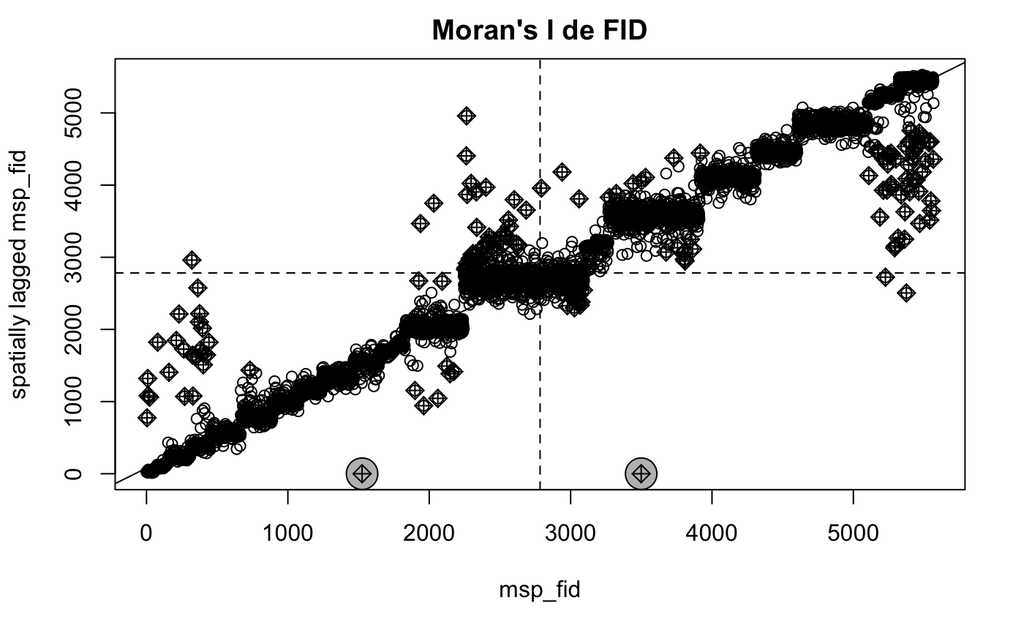

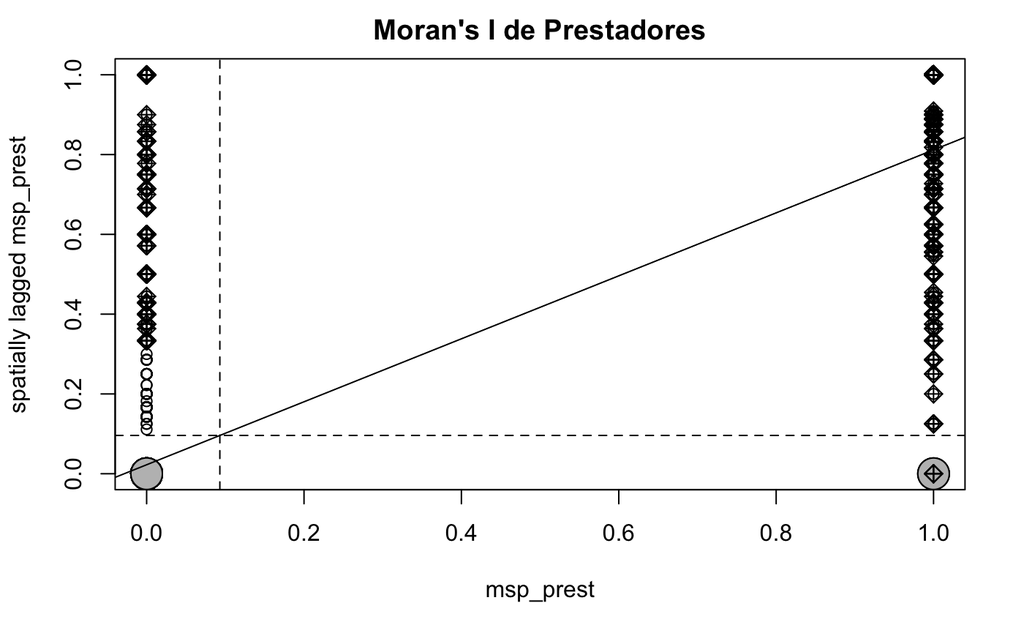

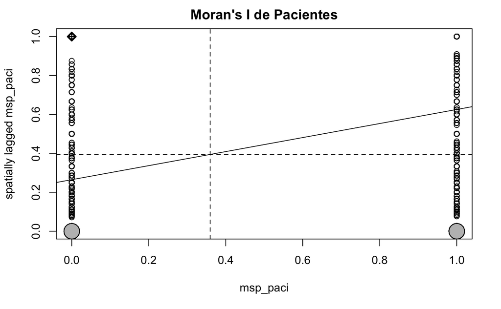

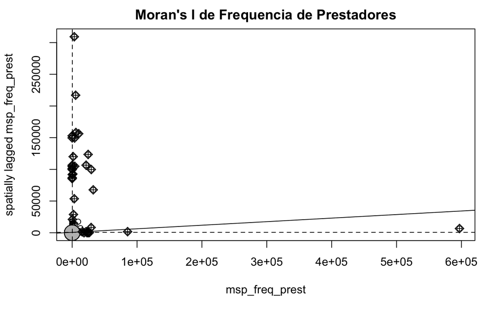

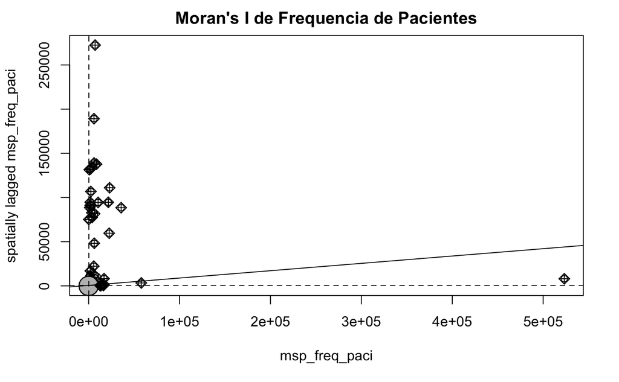

```r
{
  moran.plot(x = msp_fid, listw = munic_br_w, labels = FALSE, zero.policy = TRUE)
  title("Moran's I de FID")
  moran.plot(x = msp_prest, listw = munic_br_w, labels = FALSE, zero.policy = TRUE)
  title("Moran's I de Prestadores")
  moran.plot(x = msp_paci, listw = munic_br_w, labels = FALSE, zero.policy = TRUE)
  title("Moran's I de Pacientes")
  moran.plot(x = msp_freq_prest, listw = munic_br_w, labels = FALSE, zero.policy = TRUE)
  title("Moran's I de Frequencia de Prestadores")
  moran.plot(x = msp_freq_paci, listw = munic_br_w, labels = FALSE, zero.policy = TRUE)
  title("Moran's I de Frequencia de Pacientes")
}
```

Calculando LISA

Verificando a média de links entre vizinhos:

```r
munic_br_nb
```

```
Neighbour list object:
Number of regions: 5567
Number of nonzero links: 32892
Percentage nonzero weights: 0.1061324
Average number of links: 5.908389
2 regions with no links:
260545 352040
```

Como a média de links é 5.9, passamos este valor como parâmetro com o comando “mean(card(munic_br_nb))” para o cálculo do LISA para as variáveis:

```r
LISA_FID <- lisa(x = municip_br$lat, y = municip_br$lon, z = municip_br$fid, neigh = mean(card(munic_br_nb)))
```

```
100  of  1000
200  of  1000
300  of  1000
400  of  1000
500  of  1000
600  of  1000
700  of  1000
800  of  1000
900  of  1000
1000  of  1000
```

```r
LISA_FREQ_PREST <- lisa(x = municip_br$lat, y = municip_br$lon, z = municip_br$prestador, neigh = mean(card(munic_br_nb)))
```

```r
municip_br$LISA_FID_p <- LISA_FID$p
municip_br$LISA_FREQ_PREST_p <- LISA_FREQ_PREST$p
municip_br$LISA_FREQ_PACI_p <- LISA_FREQ_PACI$p

municip_br$LISA_FID_corr <- LISA_FID$correlation
municip_br$LISA_FREQ_PREST_corr <- LISA_FREQ_PREST$correlation
municip_br$LISA_FREQ_PACI_corr <- LISA_FREQ_PACI$correlation


tmap::tm_shape(crime_mg, simplify = 1) +
  tmap::tm_polygons() +
  tmap::tm_shape(crime_mg, simplify = 1) +
  tmap::tm_fill(c("LISA_FID_p","LISA_FID_corr"), midpoint = 0) +
  tmap::tm_style("natural")

tmap::tm_shape(crime_mg) +
  tmap::tm_polygons() +
  tmap::tm_shape(crime_mg, simplify = 1) +
  tmap::tm_fill(c("LISA_INDICE94_p","LISA_INDICE94_corr"), midpoint = 0) +
  tmap::tm_style("natural")

tmap::tm_shape(crime_mg) +
  tmap::tm_polygons() +
  tmap::tm_shape(crime_mg, simplify = 1) +
  tmap::tm_fill(c("LISA_INDICE95_p","LISA_INDICE95_corr"), midpoint = 0) +
  tmap::tm_style("natural")

tmap::tm_shape(crime_mg) +
  tmap::tm_polygons() +
  tmap::tm_shape(crime_mg, simplify = 1) +
  tmap::tm_fill(c("LISA_POP_URB_p","LISA_POP_URB_corr"), midpoint = 0) +
  tmap::tm_style("natural")
```

[output not shown]

Regressão linear simples:

```r
ap <- as.data.frame(cbind(municip_br$fid
                          , municip_br$CD_GEOCODM
                          , municip_br$freq_prest
                          , municip_br$freq_paci
                          , municip_br$prestador
                          , municip_br$paci))
colnames(ap) <- c("fid", "CD_GEOCODM","freq_prest","freq_paci","prestador","paci")

head(ap)
```

```r
lmK_m_prest <- lm(formula = municip_br$CD_GEOCODM ~ prestador, data = ap)
summary(lmK_m_prest)
```

```r
lmK_m_paci <- lm(formula = municip_br$CD_GEOCODM ~ paci, data = ap)
summary(lmK_m_paci)
```

```r
lmK_paci_prest <- lm(formula = municip_br$paci ~ prestador, data = ap)
summary(lmK_paci_prest)
```

```r
lmK_prest_paci <- lm(formula = municip_br$prestador ~ paci, data = ap)
summary(lmK_prest_paci)
```

Regressao linear espacial - SAR

Se necessário, executar novamente as 2 linhas abaixo: munic_br_nb = poly2nb(municip_br, queen=TRUE, row.names=municip_br$fid) munic_br_w <- nb2listw(munic_br_nb, style=“W”,zero.policy = TRUE)

```r
ap <- as.data.frame(cbind(municip_br$fid
                          , municip_br$CD_GEOCODM
                          , municip_br$freq_prest
                          , municip_br$freq_paci
                          , municip_br$prestador
                          , municip_br$paci))
colnames(ap) <- c("fid", "CD_GEOCODM","freq_prest","freq_paci","prestador","paci")

head(ap)
```

```r
sar.ap <- lagsarlm(municip_br$freq_prest ~ freq_paci
                   , data = ap
                   , munic_br_w
                   ,method="eigen"
                   , na.action = na.exclude)

SARk_SSE <- sar.ap$SSE

SST <- sum((ap$INDICE95 - mean(ap$INDICE95))^2)

r2_SARk <- 1 - (SARk_SSE/SST)
r2_SARk

summary(sar.ap)
```

#### Pergunta 3

##### Obs: Sugere-se fazer essa atividade no GeoDA ou no R.

```r
cat("Rˆ2 SAR: ",r2_SARk)
cat("Rˆ2 LM:",summary(lmK)$adj.r.squared)
```

#### Pergunta 4

##### Implemente a regressão espacial GWR da variável Indice95 (índice de criminalidade em 1995 de Minas Gerais) a partir de apenas uma variável independente (não pode ser Indice94, Codmuni, ID, X_coord nem Y_coord). Apresente o resultado da regressão linear simples e da regressão linear espacial por GWR. Apresente medidas da distribuição dos coeficientes (min, Q1, Q2, Q3, max), e da distribuição do R2 (min, Q1, Q2, Q3, max) e apresente os resultados globais da regressão (R2 global, basicamente).

##### Obs: Sugere-se fazer essa atividade no ArcGIS ou no R.

Regressão linear simples:

```r
ap <- as.data.frame(cbind(crime_mg$MUNIC, crime_mg$AREA, crime_mg$INDICE94,
                          crime_mg$INDICE95, crime_mg$GINI_91, crime_mg$POP_94,
                          crime_mg$POP_RUR, crime_mg$POP_URB, crime_mg$POP_FEM,
                          crime_mg$POP_MAS, crime_mg$POP_TOT, crime_mg$URBLEVEL,
                          crime_mg$PIB_PC))
colnames(ap) <- c("ID",names(crime_mg@data[4:15]))

head(ap)

lmK <- lm(formula = crime_mg$INDICE95 ~ URBLEVEL, data = ap)

summary(lmK)
```

Regressão linear GWR:

```r
coords <- cbind(crime_mg$X_COORD,crime_mg$Y_COORD)
colnames(coords) <- c("X","Y")

ap <- as.data.frame(cbind(crime_mg$MUNIC, crime_mg$AREA, crime_mg$INDICE94,
                          crime_mg$INDICE95, crime_mg$GINI_91, crime_mg$POP_94,
                          crime_mg$POP_RUR, crime_mg$POP_URB, crime_mg$POP_FEM,
                          crime_mg$POP_MAS, crime_mg$POP_TOT, crime_mg$URBLEVEL,
                          crime_mg$PIB_PC))
colnames(ap) <- c("ID",names(crime_mg@data[4:15]))

bwGauss <- gwr.sel(crime_mg$INDICE95 ~ URBLEVEL,data=ap,coords=coords,adapt=TRUE,method="aic",
                   gweight=gwr.Gauss,verbose=FALSE)

gwr.ap <- gwr(crime_mg$INDICE95 ~ URBLEVEL, data=ap,coords=coords,bandwidth=bwGauss,
               gweight=gwr.Gauss,adapt=bwGauss,hatmatrix=TRUE)
gwr.ap

GWR_SSE <- gwr.ap$results$rss
r2_GWR <- 1 - (GWR_SSE/SST)
r2_GWR
```

```r
cat("Coeficientes LM:",summary(lmK)$coefficients, "\n")
cat("Rˆ2 LM:",summary(lmK)$adj.r.squared, "\n")

cat("Coeficientes GWR:",summary(gwr.ap$lm$coefficients), "\n")
cat("Rˆ2 GWR:",r2_GWR, "\n")
```